# Final Project Report - Optimization using CVXR package

2022-12-06

# Abstract

Optimization is maximizing or minimizing a real function by systematically choosing input values from an allowed set and computing the value of the function. Means optimization is always interested in finding the best solution. Convex optimization problem is an optimization problem where you want to find a point that maximizes/minimizes the objective function through iterative computations (typically, iterative linear programming) involving convex functions. Almost all the machine learning models uses optimization techniques to find the optimal results. In this project we are optimizing Simple least squares problem, Polynomial fitting and logistic regression by replicating the data from MATLAB examples.

# Introduction

Simple least square is a common technique for estimating coefficients of linear regression. Optimizing simple least square problem is used for finding the best-fitting curve to a given set of points by minimizing the sum of the squares (“the residuals”) of the points from the curve.

When the data follows linear relationship then we fit straight line through the data points. Linear regression is single degree polynomial where degree of input variable is 1. If the data is following non-linear relationship then we need to fit a higher degree polynomial or piece wise linear regression. Here we fit higher degree polynomial curve. We followed two methods to fit the polynomial curve that is by optimizing L2 norm and L-infinity norm. L2 norm measures square root of the sum of the squared vector values. L-infinity norm measures the maximum distance.

Logistic regression is defined as a binary classification problem. Based on the logistic function, the difference between a dependent and independent variable is estimated by estimating the probability of each different occurrence. As it is an extension of linear regression used to predict continuous output variables, it is used to predict the outcome of the independent variable (1 or 0 either yes or no). In this project we are optimizing logistic regression by maximizing log likelihood function.

# Methods description

**Libraries used**

```r
library(CVXR)
library(ggplot2)
library(pracma)
library(dplyr)
library(kableExtra)
```

**Optimization of simple least square problem**

Based on the MATLAB example, we created predictor variable A and response variable b with 100 dimensions in matrix notation with random data points. Used minimize function from CVXR package to minimize the simple least square(Euclidean norm) problem.

```r
beta_r = Variable(n)
#Minimize least squares(sum(Y - X*beta)^2)
problem <- Problem(Minimize(sum((b - A %*% beta_r)^2)))
result_ls <- solve(problem)
# result_ls
#Estimated coefficient values for simple least squares regression
result_ls$getValue(beta_r)
```

```
##                [,1]
##   [1,] -0.075687154
##   [2,]  0.071164036
##   [3,]  0.102758482
##   [4,]  0.017099848
##   [5,] -0.032369787
##   [6,]  0.000479357
##   [7,] -0.251111862
##   [8,] -0.103121157
##   [9,]  0.094284304
##  [10,] -0.132183052
##  [11,] -0.112323751
##  [12,] -0.101969542
##  [13,]  0.150286646
##  [14,]  0.029303991
```

[output cut: 86 more lines]

**Polynomial fitting**

1. Estimating parameters of polynomial in case of L2-norm by solving polynomial equation in matrix notation

   $A * β = v$

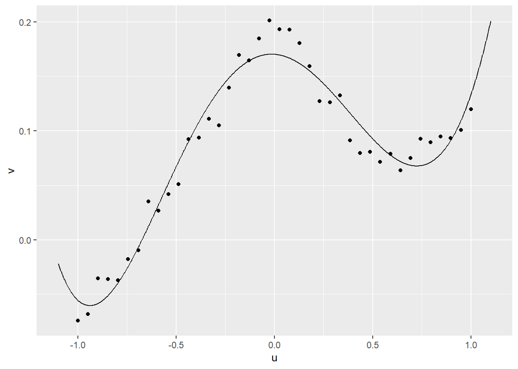

```r
A = vander(u)
A = A[,m-n+(1:n)]   #last column of A
beta <- qr.solve(A,v)  #coefficients

v_hat = A%*%beta

dd = data.frame(u, v, v_hat)
u2 = seq(-1.1, 1.1, length.out = 1000)

dd_u2 = data.frame(u2, horner(beta, u2))
ggplot()+
  geom_point(data=dd, aes(x=u,y=v))+
  geom_line(data=dd_u2, aes(x=u2, y=y))
```

2. Minimizing a cost function(L-infinity norm) - minimizing maximum error to estimate parameter coefficient

```r
beta_inf = Variable(n)

obj = norm((v - A%*%beta_inf), 'I')
prob = Problem(Minimize(expr=obj))
result = solve(prob)

beta_inf = unlist(result[1][1], use.names=FALSE)

v_hat_inf = A%*%(beta_inf)

dd_inf = data.frame(u, v, v_hat_inf)

dd_u2_inf = data.frame(u2, horner(beta_inf, u2))
```

Plot to view the results

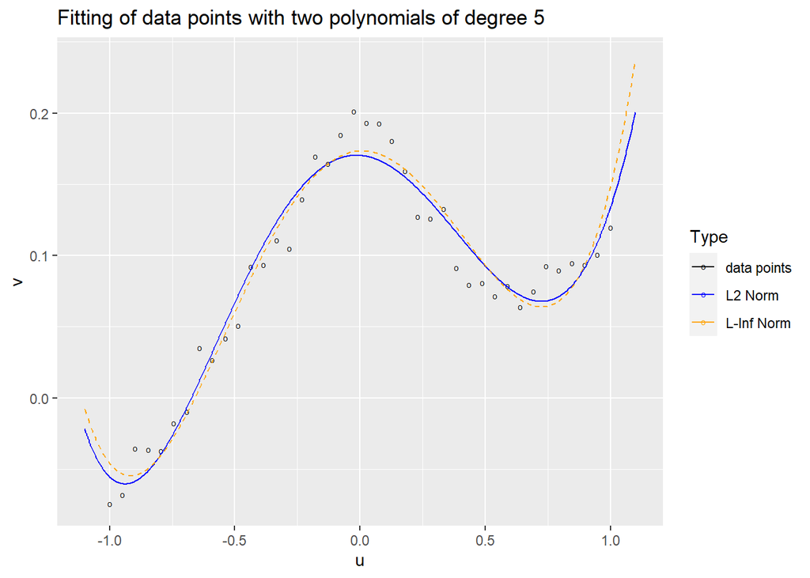

```r
ggplot()+
  geom_point(data=dd_inf, aes(x=u,y=v, color='data points'), shape='o')+
  geom_line(data=dd_u2, aes(x=u2, y=y, color='L2 Norm'))+
  geom_line(data=dd_u2_inf, aes(x=u2, y=y, color='L-Inf Norm'), linetype='dashed')+
  scale_color_manual(name = "Type", values = c("data points"="black", "L2 Norm"="blue", "L-Inf Norm"="orange"))+
  ggtitle("Fitting of data points with two polynomials of degree 5")
```

**Logistic Regression**

```r
a = 1
b = -5
m = 100
#set.seed(183991)
u = 10 * runif(n = m, min=1e-12, max=.9999999999)
```

We consider a binary random variable y with $P(y=1) = p$ and $P(y=0) = 1-p$ . We assume that that y depends on a vector of explanatory variables u in R^n. The logistic model has the sigmoid form $p = exp(a’u+b)/(1+exp(a’u+b))$ , where a and b are the model parameters. We have m data points $(u_1,y_1),…,(u_m,y_m)$ . We can reorder the data so that for $u_1,..,u_q$ the outcome is y = 1 and for $u_(q+1),…,u_m$ the outcome is y = 0.

We used custom function to apply sigmoid function $p = exp(a'u+b)/(1+exp(a'u+b))$ to convert in the scale of 0 to 1.

```r
a = 1
b = -5
m = 100
#set.seed(183991)
u = 10 * runif(n = m, min=1e-12, max=.9999999999)

Sigmoid_fn <- function(a,b,u_i = 0){
  result = exp( ((a * u_i) + b)  )
  result = result/( 1 + result)
  return(result)
}

y = c()
for(i in 1:m){
  y[i] = Sigmoid_fn(a,a, u[i])
}

for(i in 1:m){
  if (runif(n = 1, min=1e-12, max=.9999999999) < Sigmoid_fn(a,b, u[i]) ){
    y[i] = 1
  } else{
    y[i] = 0
  }
}
par(mar=c(1, 1, 1, 1))
```

We optimized the logistic regression by maximizing the log likelihood of the function

$Maximize$ $\sum_{i=1}^{q} {uilog(p(u_{i}))+(1−b_{i})log(1−p(x_{i}))}$ .

```r
u1 = c( u[which(y == 1)], u[which(y == 0)]  )
y1 = c( y[which(y == 1)], y[which(y == 0)]  )


aml = Variable(1)
bml = Variable(1)

obj <- sum((u1[ y1 == 1] %*% aml) + bml)  - sum(logistic((u1 %*% aml) + bml) )
prob <- Problem(Maximize(obj))
result <- solve(prob)

result$status
```

```
## [1] "optimal"
```

```r
result$value
```

```
## [1] -21.9867
```

```r
result$getValue(aml)
```

```
## [1] 1.309951
```

```r
result$getValue(bml)
```

```
## [1] -5.862803
```

```r
aml_value = result$getValue(aml)
bml_value = result$getValue(bml)

y_ml = c()
for(i in 1:m){
  y_ml[i] = Sigmoid_fn(aml_value,bml_value, u[i])
}
```

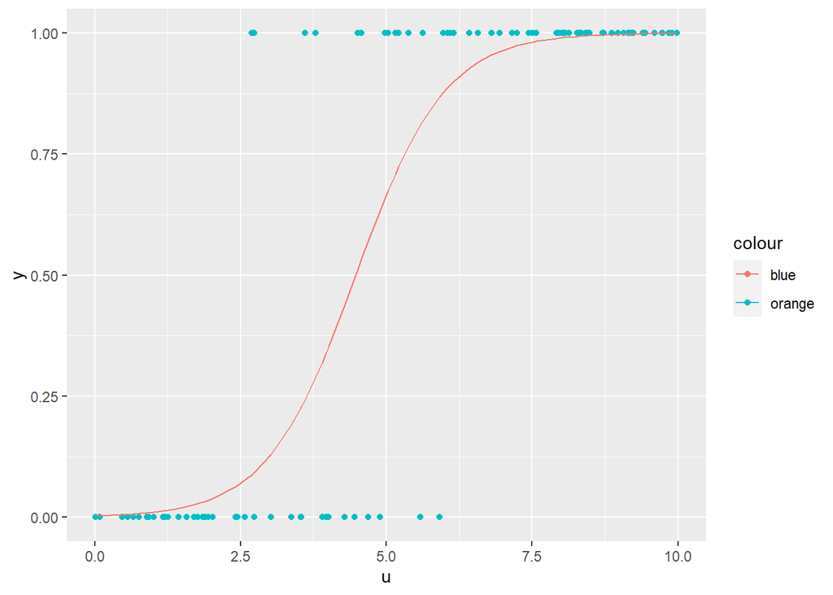

```r
df <- data.frame(
  u = u,
  y = y,
  y_ml = y_ml)

ggplot()+
  geom_point(data=df, aes(x=u,y=y, color = 'orange'))+
  geom_line(data=df, aes(x=u, y=y_ml, color = 'blue'))
```

**Conclusions**

For simple least square problem, the minimize function has reduced/minimized $\beta$ coefficients to reduce the residuals to fit the best fit line with minimum error. For polynomial fitting by optimizing L-${\infty}$ norm made curve towards the outlier which is having maximum distance among the data points. L- ${\infty}$ seems prone to outliers, outliers must be removed before optimizing L-${\infty}$ norm. For logistic regression, the maximize function has been maximized log likelihood function to get the better results from logistic regression.

**Appendix**

References

1. Convex optimization in R https://cvxr.rbind.io/
2. Example library http://web.cvxr.com/cvx/examples/index.html
3. GitHub Link: https://github.com/MownikaKonamaneni/Projects-dataScience/tree/main/Final%20Project%20-%20Scientific%20Computation%20and%20Programming